# Pattern Recognition using Motif Detection in Time Series

Jamie Reilly, Ph.D.

2018-11-06

# Introduction

Our aim is to evaluate whether a machine can detect a recurring sequential pattern within a univariate time series (i.e., a single vector of observations that are temporally ordered and autocorrelated). This just looks like a long vector of numbers. These numbers could reflect continuous measurement of temperatures, pupil size, etc. Here are the libraries we’ll use –

```r
library(TraMineR)
library(zoo)
library(tidyverse)
library(TSMining)
```

```r
signal1 <- data.frame(rep(seq(1, 10), 10))
colnames(signal1) <- "obs"
signal2 <- data.frame(rep(c(21, 22, 23, 24, 25, 24, 22, 21), 10))
colnames(signal2) <- "obs"
```

What’s a signal withut noise? Let’s embed our two motifs into a noise distribution. We’ll create this by randomly sampling integers 1-40 with replacement (200 observations) then combine signal1, signal2, and noise into a single vector. Convert that to a time series object, and plot it.

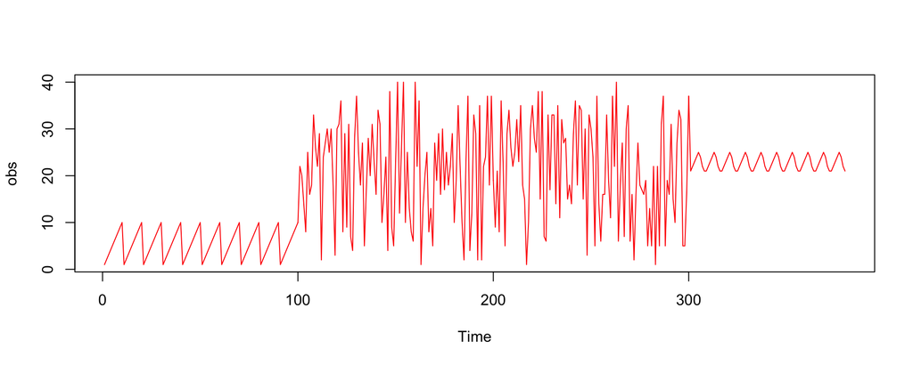

```r
noise <- data.frame(sample(c(1:40), 200, replace = T))
colnames(noise) <- "obs"
both <- rbind(signal1, noise, signal2)
both.ts <- as.ts(both)
plot.ts(both.ts, col = "red")
```

We have reached the critical point where we need to see if an agnostic (unsupervised) machine learning algoirthm can detect and extract the two motifs using univariate motif detection. We won’t tell it what to look for (that’s the unsupervised part), but we know the ground truth in advance. It needs to detect two motifs….and so it does.

```r
both.look <- Func.motif(ts = both.ts, global.norm = T, local.norm = F, window.size = 20,
    overlap = 0, w = 6, a = 5, mask.size = 5, max.dist.ratio = 1.2, count.ratio.1 = 1.1,
    count.ratio.2 = 1.1)
length(both.look$Indices)
```

```
## [1] 2
```

Next step – get ggplot2 to identify and color the two motifs within the original time series.

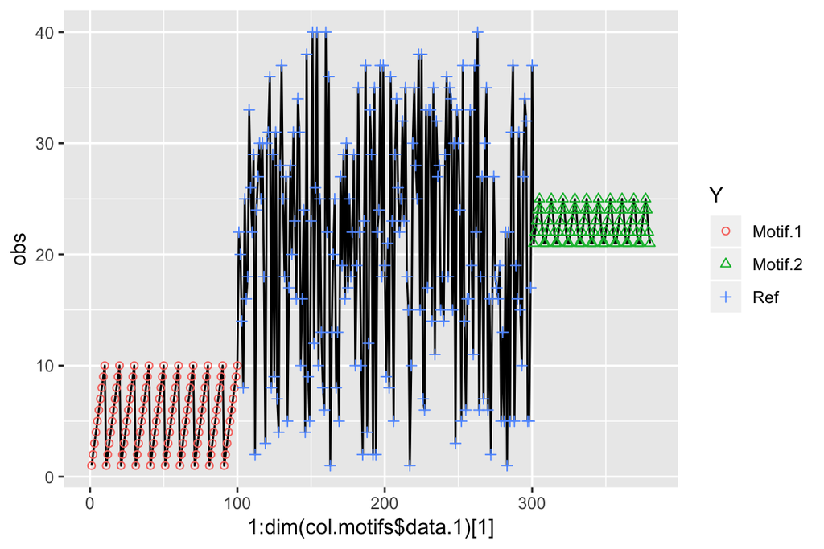

```r
col.motifs <- Func.visual.SingleMotif(single.ts = both.ts, window.size = 20,
    motif.indices = both.look$Indices)

# Determine the total number of motifs discovered
n <- length(unique(col.motifs$data.1$Y))

# plot it
ggplot(data = col.motifs$data.1) + geom_line(aes(x = 1:dim(col.motifs$data.1)[1],
    y = obs)) + geom_point(aes(x = 1:dim(col.motifs$data.1)[1], y = obs, color = Y,
    shape = Y)) + scale_shape_manual(values = seq(1:n))
```

That worked great. The algorithm detected and colored the two motifs. Now let’s get ggplot to extract and plot the individual motifs from the original time series. This code was adapted from https://cran.r-project.org/web/packages/TSMining/vignettes/MotifDiscovery.html

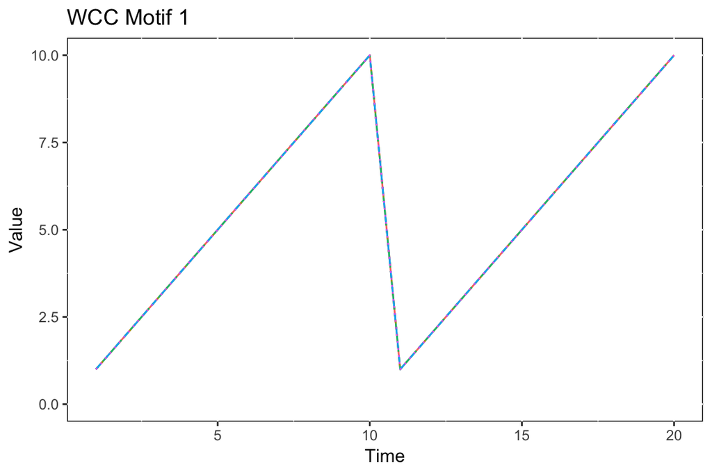

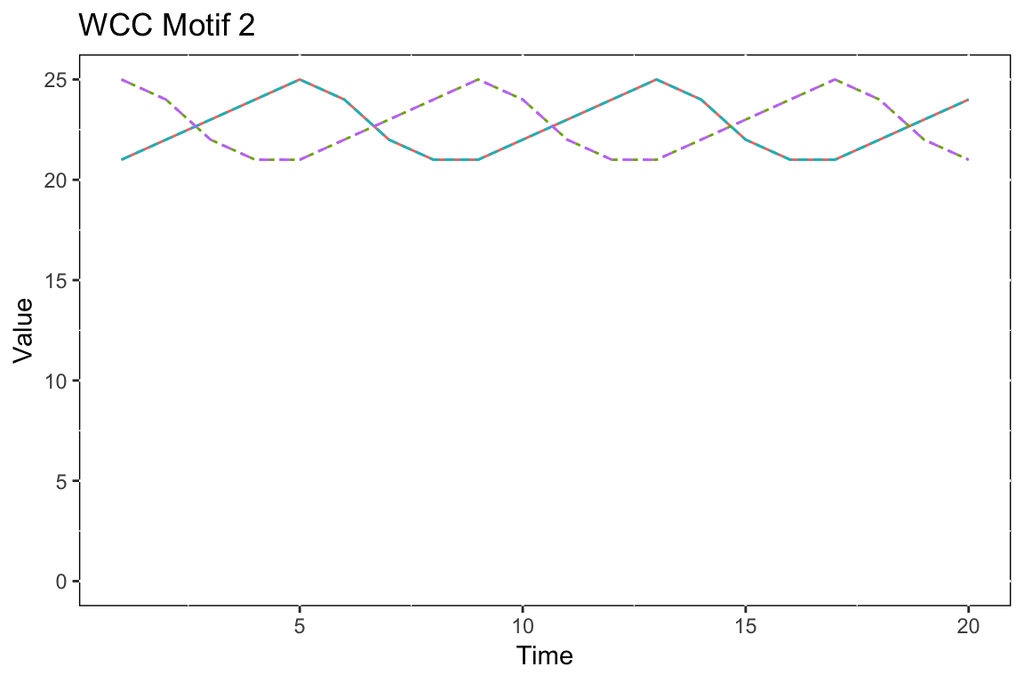

```r
for (i in 1:length(col.motifs$data.2)) {
    data.temp <- col.motifs$data.2[[i]]
    print(ggplot(data = data.temp) + geom_line(aes(x = Time, y = Value, color = Instance,
        linetype = Instance)) + ggtitle(paste0("WCC Motif ", i)) + scale_y_continuous(limits = c(0,
        max(data.temp$Value))) + theme(panel.background = element_rect(fill = "white",
        colour = "black"), legend.position = "none", legend.title = element_blank()))
}
```